# Financial Data Modeling

The idea for doing this project comes from the book [Doing Data Science](https://www.amazon.com/Doing-Data-Science-Straight-Frontline/dp/1449358659) by Cathy O'Neil and Rachel Schutt.

### Goals

Gather financial data and create and investigate potential features for modeling use cases. Compute daily log returns and log Volume data. Generate a volatility index that looks at an exponentially weighted window function of the variance. Generate simple linear forecasting models based on these features. Compare a strategy using these models with a random model and a buy and hold model.

- Generate linear models using recent log returns, volume and volatility estimates.
- Look for correlations with volatility and intraday high and low ticker based features from today with tomorrow's close.
- Apply the model to future data and calculate returns on investment.
- Compare the model returns to simply buying and holding the stock as well as stochastically buying and selling the stock.

```python
import pandas as pd
import numpy as np
import matplotlib.pyplot as plt
%matplotlib inline
```

```python
import pandas_datareader
```

```python
## Get some financial data
## Quandl - is a private a financial data provider.

start_date = '1990-01-01'
end_date = '2018-11-12'

# Quandl Key, add here:
key="YOURKEYHERE"
# this is the sp500 - just the daily value
sp_code="MULTPL/SP500_REAL_PRICE_MONTH"


## To start = let's use an index
#q1 = pandas_datareader.quandl.QuandlReader("AMZN",  start_date, end_date, api_key=key)
#q2 = pandas_datareader.quandl.QuandlReader("GOOGL",  start_date, end_date, api_key=key)
q3 = pandas_datareader.quandl.QuandlReader("AAPL",  start_date, end_date, api_key=key)
#q4 = pandas_datareader.quandl.QuandlReader("FB",  start_date, end_date, api_key=key)
#q = pandas_datareader.quandl.QuandlReader(sp_code,  start_date, end_date, api_key=key)
#amzn=q1.read()
#goog=q2.read()
aapl=q3.read()
```

```python
# Note - data stops around 3/27/2018
# In previous notebooks I've looked at this data in more depth, here we'll take a peak,
# and then do a series of transformations before we look at modeling results

#print(amzn.shape, amzn.index.min(),amzn.index.max())
#print(goog.shape, goog.index.min(),goog.index.max())
print(aapl.shape, aapl.index.min(),aapl.index.max())
```

```
((7113, 12), Timestamp('1990-01-02 00:00:00'), Timestamp('2018-03-27 00:00:00'))
```

```python
# Aapl
aapl.head()
```

| Date | Open | High | Low | Close | Volume | ExDividend | SplitRatio | AdjOpen | AdjHigh | AdjLow | AdjClose | AdjVolume |
| --- | --- | --- | --- | --- | --- | --- | --- | --- | --- | --- | --- | --- |
| 2018-03-27 | 173.68 | 175.15 | 166.92 | 168.340 | 38962839.0 | 0.0 | 1.0 | 173.68 | 175.15 | 166.92 | 168.340 | 38962839.0 |
| 2018-03-26 | 168.07 | 173.10 | 166.44 | 172.770 | 36272617.0 | 0.0 | 1.0 | 168.07 | 173.10 | 166.44 | 172.770 | 36272617.0 |
| 2018-03-23 | 168.39 | 169.92 | 164.94 | 164.940 | 40248954.0 | 0.0 | 1.0 | 168.39 | 169.92 | 164.94 | 164.940 | 40248954.0 |
| 2018-03-22 | 170.00 | 172.68 | 168.60 | 168.845 | 41051076.0 | 0.0 | 1.0 | 170.00 | 172.68 | 168.60 | 168.845 | 41051076.0 |
| 2018-03-21 | 175.04 | 175.09 | 171.26 | 171.270 | 35247358.0 | 0.0 | 1.0 | 175.04 | 175.09 | 171.26 | 171.270 | 35247358.0 |

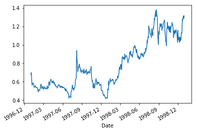

```python
## Ok - a while ago the adjusted close values are pretty low!
aapl[(aapl.index>'1997') & (aapl.index<'1999') ].AdjClose.plot()
```

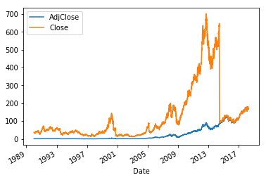

```python
# Oh right - there was a bit split a few years back
aapl[['AdjClose','Close']].plot()
```

## Transormations on the data

First transform the data so that it is feasible to generate linear models with y = Bx + C and find B and C that are the best fit to the data

- Reorder so that oldest is at the top.
- Add Log Returns (log(AdjClose_t1) - Log(AdjClose_t0)), and normalized Log Returns . (LR, NLR)
- Add Volume Returns (log(AdjVolume_t1) - Log(AdjVolume_t0))
- Add Interday Volatility (AdjHigh - AdjLow)/AdjClose

```python
# Transformations we'll do:
#
aapl=aapl.reindex(index=aapl.index[::-1])
aapl['LR']=aapl[['AdjClose']].apply(lambda x: np.log(x) - np.log(x.shift(1)))
aapl['NLR']=(aapl.LR - aapl.LR.mean())/aapl.LR.std()
aapl['vol']=aapl.LR.ewm(halflife=0.97).std()
aapl['LV']=aapl[['AdjVolume']].apply(lambda x: np.log(x) - np.log(x.shift(1)))
aapl['IV']=(aapl.AdjHigh - aapl.AdjLow)/aapl.AdjClose
aapl['IC']=(aapl.AdjClose - aapl.AdjLow)/(aapl.AdjHigh - aapl.AdjLow)
```

```python
aapl[['LR','NLR','vol','LV','IV','IC']].head()
```

| Date | LR | NLR | vol | LV | IV | IC |
| --- | --- | --- | --- | --- | --- | --- |
| 1990-01-02 | NaN | NaN | NaN | NaN | 0.067114 | 0.900000 |
| 1990-01-03 | 0.006689 | 0.207857 | NaN | 0.126945 | 0.013333 | 0.000000 |
| 1990-01-04 | 0.003461 | 0.095719 | 0.002283 | 0.062969 | 0.039862 | 0.253333 |
| 1990-01-05 | 0.003184 | 0.086104 | 0.001576 | -0.585766 | 0.033113 | 0.600000 |
| 1990-01-08 | 0.006601 | 0.204789 | 0.002081 | -0.193942 | 0.026316 | 1.000000 |

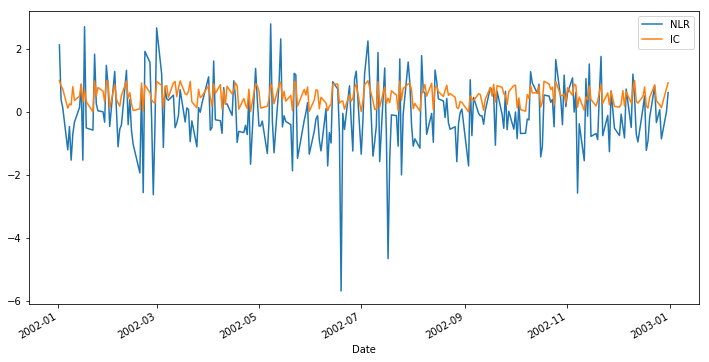

```python
# Look at the log return and Inter Close
aapl[(aapl.index > '2002') & (aapl.index < '2003')][['NLR','IC']].plot(figsize=(12,6))
```

```python
# Are there any interesting correlations?
aapl[(aapl.index > '2002') & (aapl.index < '2003')][['NLR','IC']].corr()
```

|  | NLR | IC |
| --- | --- | --- |
| NLR | 1.000000 | 0.696897 |
| IC | 0.696897 | 1.000000 |

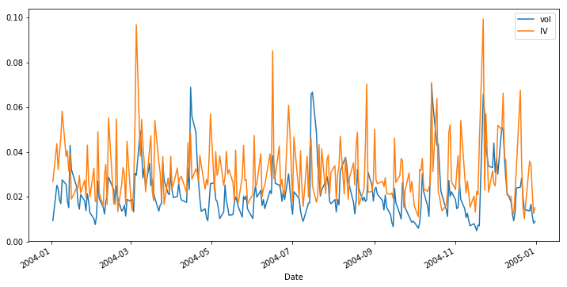

```python
## Look at the volatility and the Interday Volatility
aapl[(aapl.index > '2004') & (aapl.index < '2005')][['vol','IV']].plot(figsize=(12,6))
```

```python
## are the vols correlated?
aapl[(aapl.index > '2004') & (aapl.index < '2005')][['vol','IV']].corr()
```

|  | vol | IV |
| --- | --- | --- |
| vol | 1.000000 | 0.429172 |
| IV | 0.429172 | 1.000000 |

```python
# Ok, now add previous days data:
# This will add the LR-1 as previous NormedLR, making it available for a y = Ax + B type linear problem.
# Since data is ordered old => new, a positive shift, shifts the index "upwards" and gets older data
aapl['NLR-1']=aapl[['NLR']].apply(lambda x: x.shift(1))
aapl['NLR-2']=aapl[['NLR']].apply(lambda x: x.shift(2))
aapl['NLR-3']=aapl[['NLR']].apply(lambda x: x.shift(3))
aapl['NLR-4']=aapl[['NLR']].apply(lambda x: x.shift(4))
```

```python
# And the future value - what the model is to predict, y = NLR+1
aapl['NLR+1']=aapl[['NLR']].apply(lambda x: x.shift(-1))
```

```python
# Peak at this:
aapl[['LR', 'AdjClose','NLR+1','NLR','NLR-1','NLR-2','NLR-3','NLR-4','vol','LV','AdjVolume','IV','IC']].head(6)
```

| Date | LR | AdjClose | NLR+1 | NLR | NLR-1 | NLR-2 | NLR-3 | NLR-4 | vol | LV | AdjVolume | IV | IC |
| --- | --- | --- | --- | --- | --- | --- | --- | --- | --- | --- | --- | --- | --- |
| 1990-01-02 | NaN | 1.118093 | 0.207857 | NaN | NaN | NaN | NaN | NaN | NaN | NaN | 45799600.0 | 0.067114 | 0.900000 |
| 1990-01-03 | 0.006689 | 1.125597 | 0.095719 | 0.207857 | NaN | NaN | NaN | NaN | NaN | 0.126945 | 51998800.0 | 0.013333 | 0.000000 |
| 1990-01-04 | 0.003461 | 1.129499 | 0.086104 | 0.095719 | 0.207857 | NaN | NaN | NaN | 0.002283 | 0.062969 | 55378400.0 | 0.039862 | 0.253333 |
| 1990-01-05 | 0.003184 | 1.133101 | 0.204789 | 0.086104 | 0.095719 | 0.207857 | NaN | NaN | 0.001576 | -0.585766 | 30828000.0 | 0.033113 | 0.600000 |
| 1990-01-08 | 0.006601 | 1.140605 | -0.364365 | 0.204789 | 0.086104 | 0.095719 | 0.207857 | NaN | 0.002081 | -0.193942 | 25393200.0 | 0.026316 | 1.000000 |
| 1990-01-09 | -0.009785 | 1.129499 | -1.562685 | -0.364365 | 0.204789 | 0.086104 | 0.095719 | 0.207857 | 0.009535 | -0.164811 | 21534800.0 | 0.026575 | 0.630000 |

```python
aapl[['LR', 'AdjClose','NLR+1','NLR','NLR-1','NLR-2','NLR-3','NLR-4','vol','LV','IV','IC']].describe().transpose()
```

|  | count | mean | std | min | 25% | 50% | 75% | max |
| --- | --- | --- | --- | --- | --- | --- | --- | --- |
| LR | 7112.0 | 7.050564e-04 | 0.028789 | -0.731247 | -0.012852 | 0.000054 | 0.014317 | 0.286796 |
| AdjClose | 7113.0 | 2.828904e+01 | 43.039528 | 0.415743 | 1.229236 | 3.080479 | 43.196105 | 181.720000 |
| NLR+1 | 7112.0 | 4.247633e-17 | 1.000000 | -25.424949 | -0.470909 | -0.022607 | 0.472828 | 9.937587 |
| NLR | 7112.0 | 4.247633e-17 | 1.000000 | -25.424949 | -0.470909 | -0.022607 | 0.472828 | 9.937587 |
| NLR-1 | 7111.0 | 1.303291e-04 | 1.000010 | -25.424949 | -0.470355 | -0.022505 | 0.472882 | 9.937587 |
| NLR-2 | 7110.0 | -9.279425e-05 | 0.999903 | -25.424949 | -0.470618 | -0.022607 | 0.472579 | 9.937587 |
| NLR-3 | 7109.0 | 2.497108e-05 | 0.999924 | -25.424949 | -0.469828 | -0.022505 | 0.472775 | 9.937587 |
| NLR-4 | 7108.0 | 9.810736e-05 | 0.999976 | -25.424949 | -0.469301 | -0.022386 | 0.472828 | 9.937587 |
| vol | 7111.0 | 2.297688e-02 | 0.017499 | 0.001576 | 0.012274 | 0.019062 | 0.028985 | 0.470795 |
| LV | 7112.0 | -2.273158e-05 | 0.436074 | -4.030927 | -0.260247 | -0.022251 | 0.236022 | 4.025519 |
| IV | 7113.0 | 3.302855e-02 | 0.021041 | 0.003953 | 0.018308 | 0.028265 | 0.041760 | 0.277191 |
| IC | 7113.0 | 5.094351e-01 | 0.307046 | 0.000000 | 0.239617 | 0.500000 | 0.786885 | 1.000000 |

```python
## The modeling process could be as simple as seeing if there's any correlation with NLR+1 with any variable?
aapl[(aapl.index > '2002') & (aapl.index < '2003')][['NLR+1', 'AdjClose','NLR+1','NLR','NLR-1','NLR-2','NLR-3','NLR-4','vol','LV','IV','IC']].corr()
```

|  | NLR+1 | AdjClose | NLR+1 | NLR | NLR-1 | NLR-2 | NLR-3 | NLR-4 | vol | LV | IV | IC |
| --- | --- | --- | --- | --- | --- | --- | --- | --- | --- | --- | --- | --- |
| NLR+1 | 1.000000 | -0.063285 | 1.000000 | -0.024893 | -0.124988 | -0.092695 | 0.089660 | -0.018519 | 0.011842 | 0.019582 | 0.080712 | -0.101481 |
| AdjClose | -0.063285 | 1.000000 | -0.063285 | 0.085514 | 0.081302 | 0.063937 | 0.054149 | 0.069897 | 0.048722 | 0.010819 | -0.004778 | 0.126551 |
| NLR+1 | 1.000000 | -0.063285 | 1.000000 | -0.024893 | -0.124988 | -0.092695 | 0.089660 | -0.018519 | 0.011842 | 0.019582 | 0.080712 | -0.101481 |
| NLR | -0.024893 | 0.085514 | -0.024893 | 1.000000 | -0.033522 | -0.119694 | -0.081344 | 0.090525 | -0.049604 | -0.067566 | -0.014254 | 0.696897 |
| NLR-1 | -0.124988 | 0.081302 | -0.124988 | -0.033522 | 1.000000 | -0.035378 | -0.120355 | -0.082399 | -0.098442 | 0.017899 | -0.061903 | 0.044624 |
| NLR-2 | -0.092695 | 0.063937 | -0.092695 | -0.119694 | -0.035378 | 1.000000 | -0.032962 | -0.119734 | -0.051526 | 0.001735 | -0.063011 | -0.016333 |
| NLR-3 | 0.089660 | 0.054149 | 0.089660 | -0.081344 | -0.120355 | -0.032962 | 1.000000 | -0.031626 | -0.083384 | 0.062351 | -0.018205 | -0.054379 |
| NLR-4 | -0.018519 | 0.069897 | -0.018519 | 0.090525 | -0.082399 | -0.119734 | -0.031626 | 1.000000 | -0.066132 | 0.031008 | -0.097918 | 0.136069 |
| vol | 0.011842 | 0.048722 | 0.011842 | -0.049604 | -0.098442 | -0.051526 | -0.083384 | -0.066132 | 1.000000 | 0.071383 | 0.475645 | 0.037181 |
| LV | 0.019582 | 0.010819 | 0.019582 | -0.067566 | 0.017899 | 0.001735 | 0.062351 | 0.031008 | 0.071383 | 1.000000 | 0.308876 | 0.043641 |
| IV | 0.080712 | -0.004778 | 0.080712 | -0.014254 | -0.061903 | -0.063011 | -0.018205 | -0.097918 | 0.475645 | 0.308876 | 1.000000 | 0.000201 |
| IC | -0.101481 | 0.126551 | -0.101481 | 0.696897 | 0.044624 | -0.016333 | -0.054379 | 0.136069 | 0.037181 | 0.043641 | 0.000201 | 1.000000 |

## Testing and Applying Models - Part 1

Now that we've prepared historic data we'd like to test and apply a predictive model and strategy for trading securities. Here is my initial work that explores the code used to create the different model returns.

- Does a model trained in the past predict closes in the future?
- (Also, does a model trained in the future, predict closes in the past?)
- Does a model beat just holding the stock?
- Does a model beat a simple stochastic one??

```python
## How do I see how much just holding AAPL would do?
# Let's say I make a bet of 1000 shares.  What would happen?

hold = aapl[(aapl.index > '2002') & (aapl.index < '2003')][['AdjClose','LR']]

# Calculate the daily change by looking at the Return from the previous day, and multiplying by previous days price
hold['daily_change']=1000*(np.exp(hold['LR'])-1)*hold['AdjClose'].shift(1)
hold['investment_value']=1000*hold.AdjClose

initial_investment=1000*hold[hold.index==hold.index.min()].AdjClose[0]

# This works - but is hella ugly
#hold['overall_return']=np.ones(hold.count()[0])*initial_investment[0]*hold.AdjClose

hold['overall_return']=1000*hold.AdjClose - initial_investment
```

```python
# calculate daily change, by looking at overall_return_1 - overall_return_0
hold['daily_change2']=hold[['overall_return']].apply(lambda x: x - x.shift(1))
hold['overall_return2']=hold.daily_change2.cumsum()
```

```python
# checksum:
hold['chksm1']=hold['overall_return2']-hold['overall_return']
hold.chksm1.sum()
```

```
0.0
```

```python
del hold['chksm1']
hold.head()
```

| Date | AdjClose | LR | daily_change | investment_value | overall_return | daily_change2 | overall_return2 |
| --- | --- | --- | --- | --- | --- | --- | --- |
| 2002-01-02 | 1.497187 | 0.061967 | NaN | 1497.187374 | 0.000000 | NaN | NaN |
| 2002-01-03 | 1.515179 | 0.011946 | 17.991951 | 1515.179325 | 17.991951 | 17.991951 | 17.991951 |
| 2002-01-04 | 1.522248 | 0.004654 | 7.068267 | 1522.247591 | 25.060218 | 7.068267 | 25.060218 |
| 2002-01-07 | 1.471485 | -0.033916 | -50.763005 | 1471.484586 | -25.702788 | -50.763005 | -25.702788 |
| 2002-01-08 | 1.452850 | -0.012745 | -18.634521 | 1452.850065 | -44.337308 | -18.634521 | -44.337308 |

```python
hold.tail()
```

| Date | AdjClose | LR | daily_change | investment_value | overall_return | daily_change2 | overall_return2 |
| --- | --- | --- | --- | --- | --- | --- | --- |
| 2002-12-24 | 0.922730 | -0.009012 | -8.353406 | 922.730072 | -574.457301 | -8.353406 | -574.457301 |
| 2002-12-26 | 0.925300 | 0.002782 | 2.570279 | 925.300351 | -571.887023 | 2.570279 | -571.887023 |
| 2002-12-27 | 0.903453 | -0.023894 | -21.847369 | 903.452982 | -593.734392 | -21.847369 | -593.734392 |
| 2002-12-30 | 0.904096 | 0.000711 | 0.642570 | 904.095551 | -593.091822 | 0.642570 | -593.091822 |
| 2002-12-31 | 0.920802 | 0.018310 | 16.706812 | 920.802363 | -576.385010 | 16.706812 | -576.385010 |

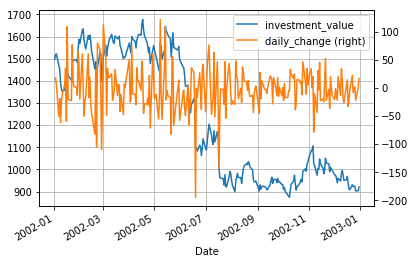

```python
# Using the plt.figure()
hold['investment_value'].plot(grid=True, legend=True)
hold['daily_change'].plot(grid=True, legend=True, secondary_y=True)
```

```python
## Ok, now lets make a stochastic model, (perhaps a few.. ) and see how how it does..
# Let's say bet on 1000 shares.  And always sell on the next day after a bet.  What would happen?
# Also - what would the range of outcomes be, etc..

# first, what is the approx number of days that returns are positive in the data?   close to 50% over all..
print(aapl[aapl.index<'2002'].count()[0])
print(aapl[(aapl.index<'2002') & (aapl.LR > 0)].count()[0])
print(np.float(aapl[(aapl.index<'2002') & (aapl.LR > 0)].count()[0]) / aapl[aapl.index<'2002'].count()[0])
```

```
3028
1425
0.470607661823
```

```python
# First cut a simple stochastic model

rand = aapl[(aapl.index > '2002') & (aapl.index < '2003')][['AdjClose','LR']]
rand['make_bet']=np.random.randint(0,2, rand.shape[0])
print("number of days: ",rand.shape[0]," bets: ",rand.make_bet.sum())
# Calculate the daily change by looking at the Return from the previous day, and multiplying by previous days price


#rand['daily_change']=1000*(np.exp(hold['LR'])-1)*hold['AdjClose'].shift(1)
rand['daily_change']=1000*rand[['AdjClose']].apply(lambda x: x - x.shift(1))
rand['investment_change']=rand['daily_change']*rand['make_bet']
rand['investment_return']=rand['investment_change'].cumsum()
```

```
('number of days: ', 252, ' bets: ', 116)
```

```python
rand.head(10)
```

| Date | AdjClose | LR | make_bet | daily_change | investment_change | investment_return |
| --- | --- | --- | --- | --- | --- | --- |
| 2002-01-02 | 1.497187 | 0.061967 | 0 | NaN | NaN | NaN |
| 2002-01-03 | 1.515179 | 0.011946 | 1 | 17.991951 | 17.991951 | 17.991951 |
| 2002-01-04 | 1.522248 | 0.004654 | 1 | 7.068267 | 7.068267 | 25.060218 |
| 2002-01-07 | 1.471485 | -0.033916 | 0 | -50.763005 | -0.000000 | 25.060218 |
| 2002-01-08 | 1.452850 | -0.012745 | 1 | -18.634521 | -18.634521 | 6.425697 |
| 2002-01-09 | 1.391163 | -0.043387 | 0 | -61.686690 | -0.000000 | 6.425697 |
| 2002-01-10 | 1.364175 | -0.019590 | 0 | -26.987927 | -0.000000 | 6.425697 |
| 2002-01-11 | 1.352609 | -0.008515 | 0 | -11.566254 | -0.000000 | 6.425697 |
| 2002-01-14 | 1.359035 | 0.004739 | 1 | 6.425697 | 6.425697 | 12.851394 |
| 2002-01-15 | 1.394376 | 0.025672 | 1 | 35.341333 | 35.341333 | 48.192727 |

```python
hold.head()
```

| Date | AdjClose | LR | daily_change | investment_value | overall_return | daily_change2 | overall_return2 |
| --- | --- | --- | --- | --- | --- | --- | --- |
| 2002-01-02 | 1.497187 | 0.061967 | NaN | 1497.187374 | 0.000000 | NaN | NaN |
| 2002-01-03 | 1.515179 | 0.011946 | 17.991951 | 1515.179325 | 17.991951 | 17.991951 | 17.991951 |
| 2002-01-04 | 1.522248 | 0.004654 | 7.068267 | 1522.247591 | 25.060218 | 7.068267 | 25.060218 |
| 2002-01-07 | 1.471485 | -0.033916 | -50.763005 | 1471.484586 | -25.702788 | -50.763005 | -25.702788 |
| 2002-01-08 | 1.452850 | -0.012745 | -18.634521 | 1452.850065 | -44.337308 | -18.634521 | -44.337308 |

```
Text(0.5,0,u'Year')
```

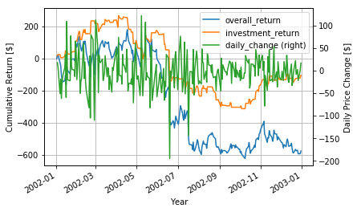

```python
# Compare the holding vs random buying and selling
ax = hold['overall_return'].plot(grid=True, legend=True)
rand['investment_return'].plot(grid=True, legend=True)
hold['daily_change'].plot(grid=True, legend=True, secondary_y=True)
ax.set_ylabel('Cumulative Return [$]')
ax.right_ax.set_ylabel('Daily Price Change [$]')
ax.set_xlabel('Year')
```

## Testing and Applying Models - Part 2

Here I train a simple linear model apply it to future data. I also compare to the "buy and hold" and "stochastic" models and generate explanatory statistics and plots.

### Goals

- generate the return comparison graphs for 3 different years, 15', 16', 17'
- generate error bars on the stochastic model
- does the stochastic model tend to the buy and hold model in the mean?

Note that the since the stochastic model chooses to bet ~ half the time, the return is roughly half of the buy and hold strategy.

```python
# Simple model -
# Train a simple model with AAPL on say 1998 to 2012, then test the model for each year post 2012

X_train = aapl[(aapl.index>'1996') & (aapl.index<'2015')][['NLR','NLR-1','NLR-2','NLR-3','vol','LV','IV','IC']]
Y_train = aapl[(aapl.index>'1996') & (aapl.index<'2015')][['NLR+1']]
```

```python
# Lets test the model on various years:  (Select out 15, 16, 17 for plots later)

X = aapl[(aapl.index>'2015') & (aapl.index<'2018')][['NLR','NLR-1','NLR-2','NLR-3','vol','LV','IV','IC']]
Y = aapl[(aapl.index>'2015') & (aapl.index<'2018')][['NLR+1']]

X15 = aapl[(aapl.index>'2015') & (aapl.index<'2016')][['NLR','NLR-1','NLR-2','NLR-3','vol','LV','IV','IC']]
Y15 = aapl[(aapl.index>'2015') & (aapl.index<'2016')][['NLR+1']]

X16 = aapl[(aapl.index>'2016') & (aapl.index<'2017')][['NLR','NLR-1','NLR-2','NLR-3','vol','LV','IV','IC']]
Y16 = aapl[(aapl.index>'2016') & (aapl.index<'2017')][['NLR+1']]

X17 = aapl[(aapl.index>'2017') & (aapl.index<'2018')][['NLR','NLR-1','NLR-2','NLR-3','vol','LV','IV','IC']]
Y17 = aapl[(aapl.index>'2017') & (aapl.index<'2018')][['NLR+1']]
```

```python
X_train.describe().transpose()
```

|  | count | mean | std | min | 25% | 50% | 75% | max |
| --- | --- | --- | --- | --- | --- | --- | --- | --- |
| NLR | 4784.0 | 0.009120 | 1.072609 | -25.424949 | -0.494113 | -0.003268 | 0.509806 | 9.937587 |
| NLR-1 | 4784.0 | 0.009229 | 1.072565 | -25.424949 | -0.493764 | -0.003268 | 0.509806 | 9.937587 |
| NLR-2 | 4784.0 | 0.009233 | 1.072563 | -25.424949 | -0.493764 | -0.003268 | 0.509806 | 9.937587 |
| NLR-3 | 4784.0 | 0.009310 | 1.072572 | -25.424949 | -0.493764 | -0.002572 | 0.509806 | 9.937587 |
| vol | 4784.0 | 0.024499 | 0.019071 | 0.001967 | 0.013005 | 0.020015 | 0.030851 | 0.470795 |
| LV | 4784.0 | -0.000127 | 0.418232 | -1.820601 | -0.250602 | -0.026271 | 0.224533 | 2.830664 |
| IV | 4784.0 | 0.034869 | 0.022401 | 0.004150 | 0.019452 | 0.029125 | 0.044096 | 0.277191 |
| IC | 4784.0 | 0.509037 | 0.310176 | 0.000000 | 0.231474 | 0.508292 | 0.788937 | 1.000000 |

```python
# Creat the model
X_train.head()
```

| Date | NLR | NLR-1 | NLR-2 | NLR-3 | vol | LV | IV | IC |
| --- | --- | --- | --- | --- | --- | --- | --- | --- |
| 1996-01-02 | 0.257739 | -0.165892 | -0.434549 | 0.320498 | 0.010242 | -0.780885 | 0.015562 | 0.760000 |
| 1996-01-03 | -0.024491 | 0.257739 | -0.165892 | -0.434549 | 0.007258 | 1.126808 | 0.031435 | 0.257426 |
| 1996-01-04 | -0.646251 | -0.024491 | 0.257739 | -0.165892 | 0.012666 | -0.359008 | 0.032003 | 0.188119 |
| 1996-01-05 | 2.816762 | -0.646251 | -0.024491 | 0.257739 | 0.056497 | 0.395767 | 0.084088 | 1.000000 |
| 1996-01-08 | 0.358777 | 2.816762 | -0.646251 | -0.024491 | 0.042763 | -1.301554 | 0.043315 | 0.420000 |

```python
Y_train.describe().transpose()
```

|  | count | mean | std | min | 25% | 50% | 75% | max |
| --- | --- | --- | --- | --- | --- | --- | --- | --- |
| NLR+1 | 4784.0 | 0.008991 | 1.072616 | -25.424949 | -0.494113 | -0.003724 | 0.509806 | 9.937587 |

```python
Y_train.head()
```

| Date | NLR+1 |
| --- | --- |
| 1996-01-02 | -0.024491 |
| 1996-01-03 | -0.646251 |
| 1996-01-04 | 2.816762 |
| 1996-01-05 | 0.358777 |
| 1996-01-08 | -1.963353 |

```python
from sklearn.linear_model import Ridge
from sklearn.linear_model import Lasso
```

```python
from sklearn.metrics import mean_squared_error
```

```python
# Actual model - lasso model
regressor = Ridge(alpha=0.5)
regressor.fit(X_train, Y_train)
```

```
Ridge(alpha=0.5, copy_X=True, fit_intercept=True, max_iter=None,
   normalize=False, random_state=None, solver='auto', tol=0.001)
```

```python
r2 = Lasso(alpha=0.0001)
r2.fit(X_train, Y_train)
```

```
Lasso(alpha=0.0001, copy_X=True, fit_intercept=True, max_iter=1000,
   normalize=False, positive=False, precompute=False, random_state=None,
   selection='cyclic', tol=0.0001, warm_start=False)
```

```python
# Predictions for each of 2015, 2016, 2017
Y_predict = regressor.predict(X)

Y15_predict = regressor.predict(X15)
Y16_predict = regressor.predict(X16)
Y17_predict = regressor.predict(X17)
```

```python
# Predictions for each of 2015, 2016, 2017 using the Lasso model
Y_predict2 = r2.predict(X)

Y15_predict2 = r2.predict(X15)
Y16_predict2 = r2.predict(X16)
Y17_predict2 = r2.predict(X17)
```

```python
mean_squared_error(Y_predict, Y)
```

```
0.2550722671112245
```

```python
mean_squared_error(Y_predict2, Y)
```

```
0.25551893583106344
```

```python
regressor.coef_
```

```
array([[ 0.00487861, -0.00553775, -0.01053907,  0.0484403 , -2.53586982,
         0.00515271,  0.77611617, -0.18425681]])
```

```python
r2.coef_
```

```
array([ 3.06115900e-03, -6.00148672e-03, -1.09980476e-02,  4.76754539e-02,
       -3.29158265e+00,  0.00000000e+00,  1.16650863e+00, -1.79054810e-01])
```

## What's in the modeled data

| Column Name | Model | Details |
| --- | --- | --- |
| daily_change | None | Difference in stock price between today and yesterday |
| hold_current_value | Hold | Today's AdjClose * Number of shares purchased, Hold investment value |
| hold_current_return | Hold | Current Return, today's investment - initial investment |
| rand_make_bet | Random | boolean on whether to buy on that day |
| rand_daily_change | Random | If a bet is made today, tomorrow will reflect that bet as (amount * daily_change) |
| predict | Predictive | Output of predictive model (Real number) |
| predict_make_bet | Predictive | Boolean output of predictive model (1 if predict > 0) |
| predict_daily_change | Predictive | If a bet is made today, tomorrow will reflect that bet as (amount * daily_change) |

```python
## Ok - gather the data for 2015


data_15 = aapl[(aapl.index > '2015') & (aapl.index < '2016')][['AdjClose','LR']]

## Random model - randomly buy and sell stock, if this is a 1, buy (and sell the next day)
data_15['rand_make_bet']=np.random.randint(0,2, data_15.shape[0])
print("Number of days: {0}".format(data_15.shape[0]))
print("Number of random bets: {0}".format(data_15.rand_make_bet.sum()))

## Recall - LR = Log(C_t/C_(t-1)))
data_15['daily_change']=(np.exp(data_15['LR'])-1)*data_15['AdjClose'].shift(1)

## Static model - buy and hold
data_15['hold_current_value']=1000*data_15.AdjClose

initial_investment15=1000*data_15[data_15.index==data_15.index.min()].AdjClose[0]
print("initial investment: {0:8.2f}".format(initial_investment15))

# This is the current Investment amount
data_15['hold_current_return']=1000*data_15.AdjClose - initial_investment15

roi_hold_net15=data_15.hold_current_return[-1:][0]

print("Final hold net return: {0:8.2f}".format(roi_hold_net15))

#rand['daily_change']=1000*(np.exp(hold['LR'])-1)*hold['AdjClose'].shift(1)
#data_15['rand_daily_change']=1000*data_15[['AdjClose']].apply(lambda x: x - x.shift(1))
data_15['rand_daily_change']=1000*data_15['daily_change']*data_15['rand_make_bet'].shift(1)
#data_15['rand_current_return']=data_15['rand_daily_change'].cumsum()

data_15['predict']=Y15_predict
data_15['predict_make_bet']=np.where(data_15['predict']>0, 1, 0)
print("Number of model bets: {0}".format(data_15.predict_make_bet.sum()))
data_15['predict_daily_change']=1000*data_15['daily_change']*data_15['predict_make_bet'].shift(1)
#data_15['predict_current_return']=data_15['predict_daily_change'].cumsum()

data_15['predict2']=Y15_predict2
data_15['predict_make_bet2']=np.where(data_15['predict2']>0, 1, 0)
print("Number of model bets: {0}".format(data_15.predict_make_bet2.sum()))
data_15['predict_daily_change2']=1000*data_15['daily_change']*data_15['predict_make_bet2'].shift(1)
#data_15['predict_current_return']=data_15['predict_daily_change'].cumsum()


# Calculate my return:
print("\nBuy and Hold Results")
print("Net gain: {0:8.2f}".format(roi_hold_net15))
prct_roi_hold15= 100*roi_hold_net15/initial_investment15
print("Percent gain: {0:2.2f} %".format(prct_roi_hold15))

print("Random Results:")
roi_rand15=data_15['rand_daily_change'].cumsum()[-1:][0]
print("Net gain: {0:8.2f}".format(roi_rand15))
prct_roi_rand15=100*(roi_rand15 ) / initial_investment15
print("Percent gain: {0:2.2f} %".format(prct_roi_rand15))

print("Model Results:")
roi_model15=data_15['predict_daily_change'].cumsum()[-1:][0]
print("Net gain: {0:8.2f}".format(roi_model15))
prct_roi_model15=100*(roi_model15 ) / initial_investment15
print("Percent gain: {0:2.2f} %".format(prct_roi_model15))

print("Model Results  (Lasso, alpha=.001):")
roi_model15_2=data_15['predict_daily_change2'].cumsum()[-1:][0]
print("Net gain: {0:8.2f}".format(roi_model15_2))
prct_roi_model15_2=100*(roi_model15_2 ) / initial_investment15
print("Percent gain: {0:2.2f} %".format(prct_roi_model15_2))
```

```
Number of days: 252
Number of random bets: 127
initial investment: 103863.96
Final hold net return: -2167.15
Number of model bets: 158
Number of model bets: 162

Buy and Hold Results
Net gain: -2167.15
Percent gain: -2.09 %
Random Results:
Net gain: -1403.68
Percent gain: -1.35 %
Model Results:
Net gain: -10773.05
Percent gain: -10.37 %
Model Results  (Lasso, alpha=.001):
Net gain: -16071.66
Percent gain: -15.47 %
```

```python
# Ok - gather the data for 2016

data_16 = aapl[(aapl.index > '2016') & (aapl.index < '2017')][['AdjClose','LR']]

## Random model - randomly buy and sell stock
data_16['rand_make_bet']=np.random.randint(0,2, data_16.shape[0])
print("Number of days: {0}".format(data_16.shape[0]))
print("Number of random bets: {0}".format(data_16.rand_make_bet.sum()))

## Recall - LR = Log(C_t/C_(t-1)))
data_16['daily_change']=(np.exp(data_16['LR'])-1)*data_16['AdjClose'].shift(1)

## Static model - buy and hgold
data_16['hold_current_value']=1000*data_16.AdjClose

initial_investment16=1000*data_16[data_16.index==data_16.index.min()].AdjClose[0]
print("initial investment: {0:8.2f}".format(initial_investment16))

data_16['hold_current_return']=1000*data_16.AdjClose - initial_investment16

roi_hold_net16=data_16.hold_current_return[-1:][0]
print("Final hold net return: {0:8.2f}".format(roi_hold_net16))


data_16['rand_daily_change']=1000*data_16['daily_change']*data_16['rand_make_bet'].shift(1)
data_16['predict']=Y16_predict
data_16['predict_make_bet']=np.where(data_16['predict']>0, 1, 0)
print("Number of model bets: {0}".format(data_16.predict_make_bet.sum()))
data_16['predict_daily_change']=1000*data_16['daily_change']*data_16['predict_make_bet'].shift(1)

data_16['predict2']=Y16_predict2
data_16['predict_make_bet2']=np.where(data_16['predict2']>0, 1, 0)
print("Number of model bets: {0}".format(data_16.predict_make_bet2.sum()))
data_16['predict_daily_change2']=1000*data_16['daily_change']*data_16['predict_make_bet2'].shift(1)
#data_15['predict_current_return']=data_15['predict_daily_change'].cumsum()


# Calculate my return:
print("Buy and Hold Results")
print("Net gain: {0:8.2f}".format(roi_hold_net16))
prct_roi_hold16= 100*roi_hold_net16/initial_investment16
print("Percent gain: {0:2.2f} %".format(prct_roi_hold16))

print("Random Results:")
roi_rand16=data_16['rand_daily_change'].cumsum()[-1:][0]
print("Net gain: {0:8.2f}".format(roi_rand16))
prct_roi_rand16=100*(roi_rand16 ) / initial_investment16
print("Percent gain: {0:2.2f} %".format(prct_roi_rand16))

print("Model Results:")
roi_model16=data_16['predict_daily_change'].cumsum()[-1:][0]
print("Net gain: {0:8.2f}".format(roi_model16))
prct_roi_model16=100*(roi_model16 ) / initial_investment16
print("Percent gain: {0:2.2f} %".format(prct_roi_model16))

print("Model Results  (Lasso, alpha=.001):")
roi_model16_2=data_16['predict_daily_change2'].cumsum()[-1:][0]
print("Net gain: {0:8.2f}".format(roi_model16_2))
prct_roi_model16_2=100*(roi_model16_2 ) / initial_investment16
print("Percent gain: {0:2.2f} %".format(prct_roi_model16_2))
```

```
Number of days: 252
Number of random bets: 128
initial investment: 101783.76
Final hold net return: 12605.69
Number of model bets: 161
Number of model bets: 167
Buy and Hold Results
Net gain: 12605.69
Percent gain: 12.38 %
Random Results:
Net gain: 27292.94
Percent gain: 26.81 %
Model Results:
Net gain: 19246.17
Percent gain: 18.91 %
Model Results  (Lasso, alpha=.001):
Net gain: 15901.36
Percent gain: 15.62 %
```

```python
# Ok - gather the data for 2017

data_17 = aapl[(aapl.index > '2017') & (aapl.index < '2018')][['AdjClose','LR']]

## Random model - randomly buy and sell stock
data_17['rand_make_bet']=np.random.randint(0,2, data_17.shape[0])
print("Number of days: {0}".format(data_17.shape[0]))
print("Number of random bets: {0}".format(data_17.rand_make_bet.sum()))

## Recall - LR = Log(C_t/C_(t-1)))
data_17['daily_change']=(np.exp(data_17['LR'])-1)*data_17['AdjClose'].shift(1)

## Static model - buy and hgold
data_17['hold_current_value']=1000*data_17.AdjClose

initial_investment17=1000*data_17[data_17.index==data_17.index.min()].AdjClose[0]
print("initial investment: {0:8.2f}".format(initial_investment17))

data_17['hold_current_return']=1000*data_17.AdjClose - initial_investment17

roi_hold_net17=data_17.hold_current_return[-1:][0]
print("Final hold net return: {0:8.2f}".format(roi_hold_net17))


data_17['rand_daily_change']=1000*data_17['daily_change']*data_17['rand_make_bet'].shift(1)
data_17['predict']=Y17_predict
data_17['predict_make_bet']=np.where(data_17['predict']>0, 1, 0)
print("Number of model bets: {0}".format(data_17.predict_make_bet.sum()))
data_17['predict_daily_change']=1000*data_17['daily_change']*data_17['predict_make_bet'].shift(1)

data_17['predict2']=Y17_predict2
data_17['predict_make_bet2']=np.where(data_17['predict2']>0, 1, 0)
print("Number of model bets: {0}".format(data_17.predict_make_bet2.sum()))
data_17['predict_daily_change2']=1000*data_17['daily_change']*data_17['predict_make_bet2'].shift(1)

# Calculate my return:
print("Buy and Hold Results 2017")
print("Net gain: {0:8.2f}".format(roi_hold_net17))
prct_roi_hold17= 100*roi_hold_net17/initial_investment17
print("Percent gain: {0:2.2f} %".format(prct_roi_hold17))

print("Random Results:")
roi_rand17=data_17['rand_daily_change'].cumsum()[-1:][0]
print("Net gain: {0:8.2f}".format(roi_rand17))
prct_roi_rand17=100*(roi_rand17 ) / initial_investment17
print("Percent gain: {0:2.2f} %".format(prct_roi_rand17))

print("Model Results:")
roi_model17=data_17['predict_daily_change'].cumsum()[-1:][0]
print("Net gain: {0:8.2f}".format(roi_model17))
prct_roi_model17=100*(roi_model17 ) / initial_investment17
print("Percent gain: {0:2.2f} %".format(prct_roi_model17))

print("Model Results  (Lasso, alpha=.001):")
roi_model17_2=data_17['predict_daily_change2'].cumsum()[-1:][0]
print("Net gain: {0:8.2f}".format(roi_model17_2))
prct_roi_model17_2=100*(roi_model17_2 ) / initial_investment17
print("Percent gain: {0:2.2f} %".format(prct_roi_model17_2))
```

```
Number of days: 249
Number of random bets: 126
initial investment: 114715.38
Final hold net return: 54514.62
Number of model bets: 158
Number of model bets: 161
Buy and Hold Results 2017
Net gain: 54514.62
Percent gain: 47.52 %
Random Results:
Net gain: 15926.57
Percent gain: 13.88 %
Model Results:
Net gain: 21241.47
Percent gain: 18.52 %
Model Results  (Lasso, alpha=.001):
Net gain: 22677.20
Percent gain: 19.77 %
```

```python
year=2015
"Investment Return on {0} in {1}".format(initial_investment, year)
```

[output not shown]

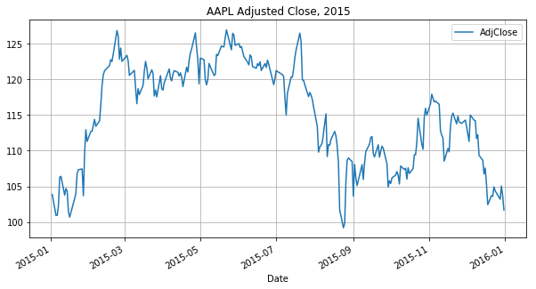

```python
# 2015 just loses, based on the last day, -2%
data_15.AdjClose.plot(legend=True,grid=True,title="AAPL Adjusted Close, 2015",figsize=(10,5))
```

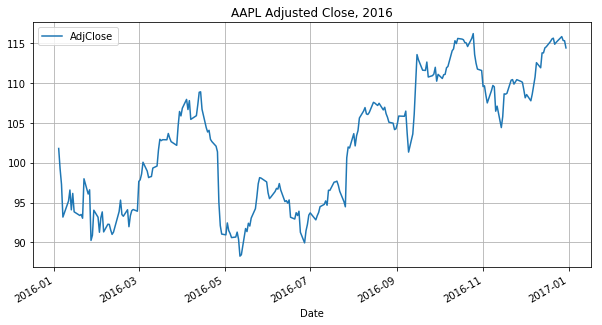

```python
# 2016 is a big win, 12%
data_16.AdjClose.plot(legend=True,grid=True,title="AAPL Adjusted Close, 2016",figsize=(10,5))
```

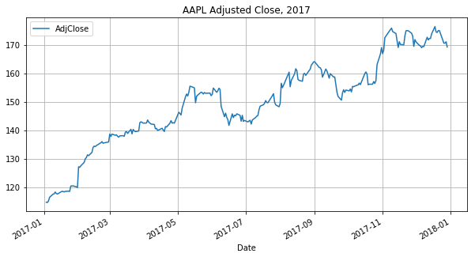

```python
# 2017 is a huge win, 46%
data_17.AdjClose.plot(legend=True,grid=True,title="AAPL Adjusted Close, 2017",figsize=(10,5))
```

```
Text(0.5,0,u'Year')
```

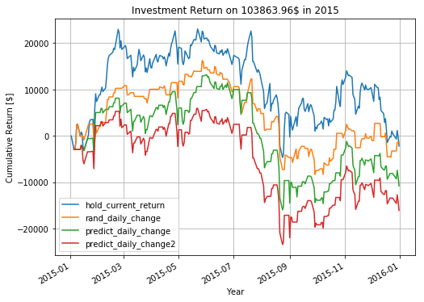

```python
## Plot the various returns - first 2015:
# Hold
# Random
# Applying the model
year=2015
ax = data_15['hold_current_return'].plot(grid=True, legend=True, figsize=(8,6),
    title="Investment Return on {0:9.2f}$ in {1}".format(initial_investment15, year))
data_15['rand_daily_change'].cumsum().plot(grid=True, legend=True)
data_15['predict_daily_change'].cumsum().plot(grid=True, legend=True)
data_15['predict_daily_change2'].cumsum().plot(grid=True, legend=True)
# data_15['daily_change'].plot(grid=True, legend=True, secondary_y=True)
ax.set_ylabel('Cumulative Return [$]')
# ax.right_ax.set_ylabel('Daily Investment Flu [$]')
ax.set_xlabel('Year')
```

```
Text(0.5,0,u'Year')
```

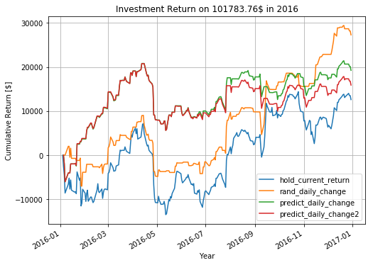

```python
## Plot the various returns:
# Hold
# Random
# Applying the model
year = 2016
ax = data_16['hold_current_return'].plot(grid=True, legend=True, figsize=(8,6),
    title="Investment Return on {0:9.2f}$ in {1}".format(initial_investment16, year))
data_16['rand_daily_change'].cumsum().plot(grid=True, legend=True)
data_16['predict_daily_change'].cumsum().plot(grid=True, legend=True)
data_16['predict_daily_change2'].cumsum().plot(grid=True, legend=True)
# data_15['daily_change'].plot(grid=True, legend=True, secondary_y=True)
ax.set_ylabel('Cumulative Return [$]')
# ax.right_ax.set_ylabel('Daily Investment Flu [$]')
ax.set_xlabel('Year')
```

```
Text(0.5,0,u'Year')
```

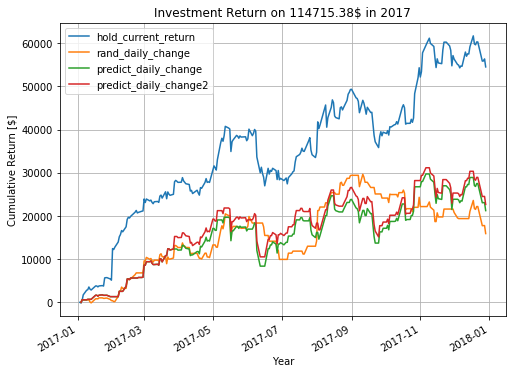

```python
## Plot the various returns:
# Hold
# Random
# Applying the model
year=2017
ax = data_17['hold_current_return'].plot(grid=True, legend=True, figsize=(8,6),
    title="Investment Return on {0:9.2f}$ in {1}".format(initial_investment17, year))
data_17['rand_daily_change'].cumsum().plot(grid=True, legend=True)
data_17['predict_daily_change'].cumsum().plot(grid=True, legend=True)
data_17['predict_daily_change2'].cumsum().plot(grid=True, legend=True)
# data_15['daily_change'].plot(grid=True, legend=True, secondary_y=True)
ax.set_ylabel('Cumulative Return [$]')
# ax.right_ax.set_ylabel('Daily Investment Flu [$]')
ax.set_xlabel('Year')
```

```python
## Ok - so these models are pretty crappy.
# what is the range of outcomes for the random models?  And what does the distribution look like?
# 1. Simulate returns on (say 1000) random models
# 2. What's the mean and std of these outcomes?


# The static data
data_test15 = aapl[(aapl.index > '2015') & (aapl.index < '2016')][['AdjClose','LR']]
data_test15['daily_change']=(np.exp(data_test15['LR'])-1)*data_test15['AdjClose'].shift(1)
results15 = np.zeros(1000)

# The stochastic model
for i in range(1000):
    data_test15['rand_make_bet']=np.random.randint(0,2, data_test15.shape[0])
    data_test15['rand_daily_change']=1000*data_test15['daily_change']*data_test15['rand_make_bet'].shift(1)
    results15[i]=data_test15['rand_daily_change'].cumsum()[-1:][0]

print("2015 Model Results: {0:8.2f}".format(results15.mean()))
print("2015 Model Results: {0:8.2f}%".format(100*(results15.mean()/initial_investment15)))
print("2015 Model Std: {0:8.2f}".format(results15.std()))
```

```
2015 Model Results:  -826.85
2015 Model Results:    -0.80%
2015 Model Std: 15080.42
```

```python
# Look at 2016
# The static data
data_test16 = aapl[(aapl.index > '2016') & (aapl.index < '2017')][['AdjClose','LR']]
data_test16['daily_change']=(np.exp(data_test16['LR'])-1)*data_test16['AdjClose'].shift(1)
results16 = np.zeros(1000)

# The stochastic model
for i in range(1000):
    data_test16['rand_make_bet']=np.random.randint(0,2, data_test16.shape[0])
    data_test16['rand_daily_change']=1000*data_test16['daily_change']*data_test16['rand_make_bet'].shift(1)
    results16[i]=data_test16['rand_daily_change'].cumsum()[-1:][0]

print("2016 Model Results: {0:8.2f}".format(results16.mean()))
print("2016 Model Results: {0:8.2f}%".format(100*(results16.mean()/initial_investment16)))
print("2016 Model Std: {0:8.2f}".format(results16.std()))
```

```
2016 Model Results:  6139.92
2016 Model Results:     6.03%
2016 Model Std: 12074.59
```

```python
# Look at 2017
# The static data
data_test17 = aapl[(aapl.index > '2017') & (aapl.index < '2018')][['AdjClose','LR']]
data_test17['daily_change']=(np.exp(data_test17['LR'])-1)*data_test17['AdjClose'].shift(1)
results17 = np.zeros(1000)

# The stochastic model
for i in range(1000):
    data_test17['rand_make_bet']=np.random.randint(0,2, data_test17.shape[0])
    data_test17['rand_daily_change']=1000*data_test17['daily_change']*data_test17['rand_make_bet'].shift(1)
    results17[i]=data_test17['rand_daily_change'].cumsum()[-1:][0]

print("2017 Model Results: {0:8.2f}".format(results17.mean()))
print("2017 Model Results: {0:8.2f}%".format(100*(results17.mean()/initial_investment17)))
print("2017 Model Std: {0:8.2f}".format(results17.std()))
```

```
2017 Model Results: 27199.69
2017 Model Results:    23.71%
2017 Model Std: 13271.84
```

## Model Results

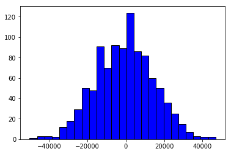

```python
# Quick and dirty histogram of the model outcomes
plt.hist(results15, color = 'blue', edgecolor = 'black', bins=25)
```

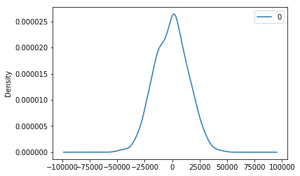

```python
# Quick and dirty density plot of the model outcomes
pd.DataFrame(results15).plot.density()
```

```
Text(0.5,0,u'Return on Investment [$]')
```

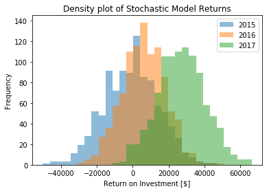

```python
ax = pd.DataFrame({'2015' : results15, '2016' : results16, '2017' : results17}).plot.hist(
    title='Density plot of Stochastic Model Returns', bins=30, alpha=0.5)
ax.set_xlabel('Return on Investment [$]')
```